# Sentiment Analysis of IMDB Movie Reviews

### M508A - Big Data Analytics

### GH1040565

# 1. Introduction and Problem

## 1.1 Business Context

In the highly competitive streaming and entertainment industry, viewer feedback is instantaneous and abundant. Every day, thousands of user reviews are sent to production studios and streaming platforms via a variety of channels. It is computationally costly, slow, and prone to human error to manually analyze this enormous volume of unstructured textual data in order to determine audience reception.

## 1.2 The Business Problem

The main problem addressed in this project is the inefficiency of manual sentiment tracking. There isn't currently an automated, scalable system in place at the company to categorize incoming viewer feedback as "Positive" or "Negative." The content team is unable to promptly respond to audience trends or recognize effective content features as a result of this lag in business intelligence.

## 1.3 Task Formulation

In Natural Language Processing (NLP), we formulate this business problem as a Binary Text Classification task.

- Input: Unprocessed text movie reviews with punctuation, mixed case, and HTML tags.
- Output: A binary label (0 = Negative, 1 = Positive)
- Goal: To create an end to end natural language processing pipeline that uses machine learning and deep learning techniques to ingest raw text, preprocess it, and classify sentiment with high accuracy.

## 1.4 Project Objectives

1. Data Ingestion: Load and inspect an uncleaned dataset
2. Preprocessing: Use a text cleaning pipeline to deal with tokenization, stopwords, and HTML tags.
3. Modeling: Use and contrast three different modeling techniques
- Statistical Baseline: Naive Bayes with TF-IDF
- Deep Learning: Word Embeddings in LSTM
- Transfer Learning: BERT
4. Evaluation: Use Accuracy, F1-Score, and Confusion Matrices to examine performance.

# 2. High-Level System Design

To solve the business problem, we propose an end to end NLP pipeline consisting of four main stages. This design ensures modularity and allows us to compare different modeling complexities.

## 2.1 The Pipeline Architecture

1. Input Layer: Raw text data ingestion (IMDb Dataset).
2. Preprocessing Layer:
- Cleaning: Removal of HTML tags, URLs, and special characters.
- Normalization: Lowercasing and Lemmatization to reduce vocabulary size.
- Tokenization: Converting text into discrete units (words or sub-words).
3. Feature Engineering & Modeling Layer:
- Approach A - Statistical: Converts text to sparse vectors using TF-IDF and classifies using Naive Bayes.
- Approach B - Sequential Neural: Converts text to dense vectors using Word Embeddings and processes sequences using LSTM.
- Approach C - Contextual Transformer: Uses BERT to generate context aware embeddings for classification.
4. Evaluation Layer: Metrics calculation to select the best model for deployment.

## 2.2 Component Justification

- We compare a deep learning model that captures sequence information and a cutting edge transformer that captures deep contextual meaning with a quick, comprehensible baseline which enables us to balance computational cost and accuracy.
- The raw data contains noise such as HTML tags and words with no meaning that adds no semantic value. Cleaning enhances model generalization and lowers the problems.

# 3. Data Acquisition

## 3.1 Data Source

The dataset is sourced from the IMDb Dataset of 50K Movie reviews available on Kaggle.

https://www.kaggle.com/datasets/lakshmi25npathi/imdb-dataset-of-50k-movie-reviews

The unclean dataset contains 50,000 reviews divided into positive and negative reviews.

## 3.2 Loading and Inspection

Importing the libraries required intitially

```python
import pandas as pd
import numpy as np
import matplotlib.pyplot as plt
import seaborn as sns
import os
```

Loading the dataset downloaed from kaggle

```python
dataset_path = '/content/IMDB Dataset.csv'

if os.path.exists(dataset_path):
    df = pd.read_csv(dataset_path)
    print("Dataset loaded successfully!")
else:
    print("Error")
```

```
Dataset loaded successfully!
```

Inpection of the dataset for its shape and no of reviews. I will also check the distribution of the sentiments

```
Dataset Shape: (50000, 2)
Columns: ['review', 'sentiment']

 Sample Reviews
```

|  | review | sentiment |
| --- | --- | --- |
| 0 | One of the other reviewers has mentioned that ... | positive |
| 1 | A wonderful little production. <br /><br />The... | positive |
| 2 | I thought this was a wonderful way to spend ti... | positive |

```
 Class Distribution
sentiment
positive    25000
negative    25000
Name: count, dtype: int64
```

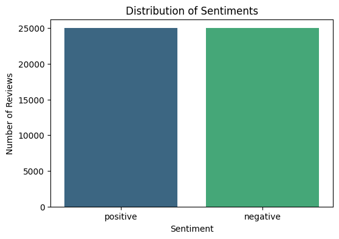

```python
print(f"\nDataset Shape: {df.shape}")
print(f"Columns: {df.columns.tolist()}")
print("\n Sample Reviews ")

display(df.head(3))

print("\n Class Distribution ")
print(df['sentiment'].value_counts())

plt.figure(figsize=(6, 4))
sns.countplot(x='sentiment', data=df, palette='viridis')
plt.title('Distribution of Sentiments')
plt.xlabel('Sentiment')
plt.ylabel('Number of Reviews')
plt.show()
```

# 4. Exploratory Data Analysis

Exploring to the dataset to determine the length of the reviews, checking for missing values and generating word clouds.

```
 Missing Values
review       0
sentiment    0
dtype: int64

 Review Length
count    50000.000000
mean       231.156940
std        171.343997
min          4.000000
25%        126.000000
50%        173.000000
75%        280.000000
max       2470.000000
Name: word_count, dtype: float64
```

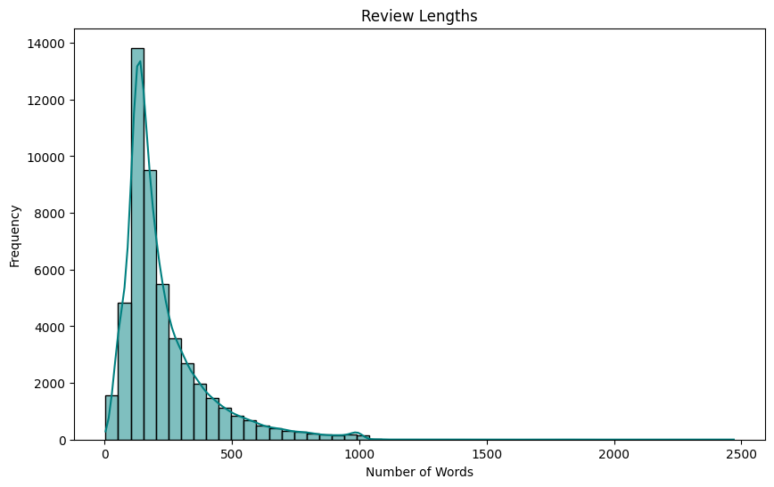

```
 Positive Reviews Word cloud
```

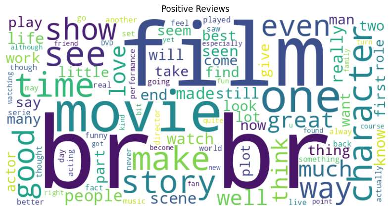

```
 Negative Reviews Word cloud
```

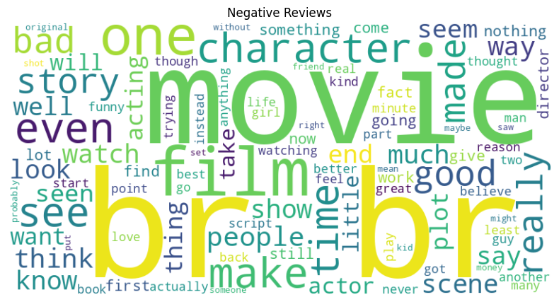

```python
from wordcloud import WordCloud

print(" Missing Values ")
print(df.isnull().sum())

df['word_count'] = df['review'].apply(lambda x: len(x.split()))

print("\n Review Length ")
print(df['word_count'].describe())

plt.figure(figsize=(10, 6))
sns.histplot(df['word_count'], bins=50, kde=True, color='teal')
plt.title('Review Lengths')
plt.xlabel('Number of Words')
plt.ylabel('Frequency')
plt.show()

def plot_wordcloud(text, title):
    wordcloud = WordCloud(width=800, height=400, background_color='white', max_words=100).generate(text)
    plt.figure(figsize=(10, 5))
    plt.imshow(wordcloud, interpolation='bilinear')
    plt.axis('off')
    plt.title(title)
    plt.show()

pos_text = " ".join(df[df['sentiment'] == 'positive']['review'])
neg_text = " ".join(df[df['sentiment'] == 'negative']['review'])

print("\n Positive Reviews Word cloud ")
plot_wordcloud(pos_text, "Positive Reviews")

print("\n Negative Reviews Word cloud ")
plot_wordcloud(neg_text, "Negative Reviews")
```

# 5: Data Preprocessing

Cleaning the data by removing the html tags and the spcial characters in the dataset.

- Removing the htm tags.
- Converting all the text to lower case.
- Removing the special characters, links and numbers.
- Removing stop words.
- Reducing words to thebase form.
- Tokenizing

```python
import re
from bs4 import BeautifulSoup
import nltk
from nltk.corpus import stopwords
from nltk.tokenize import word_tokenize
from nltk.stem import WordNetLemmatizer

nltk.download('stopwords')
nltk.download('punkt')
nltk.download('wordnet')
nltk.download('punkt_tab')

lemmatizer = WordNetLemmatizer()
stop_words = set(stopwords.words('english'))

stop_words.discard('not')
stop_words.discard('no')
stop_words.discard('nor')

def preprocess_text(text):
    """
    Input: Uncleaned raw review string.
    Output: Cleaned, lemmatized string.
    """

    soup = BeautifulSoup(text, "html.parser")
    text = soup.get_text()

    text = re.sub(r'[^a-zA-Z]', ' ', text)

    text = text.lower()

    tokens = word_tokenize(text)

    cleaned_tokens = [
        lemmatizer.lemmatize(word) for word in tokens
        if word not in stop_words and word != 'br'
    ]

    return " ".join(cleaned_tokens)

df['cleaned_review'] = df['review'].apply(preprocess_text)

print("\n Preprocessing Complete!")
```

```
 Preprocessing Complete!
```

Creating a word cloud to check the cleaned text

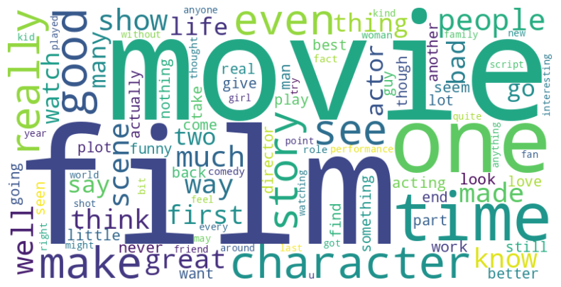

```python
from wordcloud import WordCloud

subset_clean = " ".join(df['cleaned_review'].sample(1000, random_state=42))

plt.figure(figsize=(10, 5))
wordcloud_clean = WordCloud(width=800, height=400, background_color='white', max_words=100).generate(subset_clean)
plt.imshow(wordcloud_clean, interpolation='bilinear')
plt.axis('off')
plt.show()
```

Splitting the data for training

```python
from sklearn.model_selection import train_test_split

X = df['cleaned_review']
y = df['sentiment'].apply(lambda x: 1 if x == 'positive' else 0)

X_train, X_test, y_train, y_test = train_test_split(
    X, y, test_size=0.2, random_state=42, stratify=y
)

print(f"Training Samples: {X_train.shape[0]}")
print(f"Testing Samples: {X_test.shape[0]}")
```

```
Training Samples: 40000
Testing Samples: 10000
```

# 6. Feature Engineering & Modeling

To categorize the reviews, we now use three different models.

## 6.1 Model 1: TTF-IDF Vectorization + Naive Bayes Classifier

Feature Extraction using TF-IDF and classification using Naive Bayes Classifier.

```python
df_subset = df.sample(frac=0.1, random_state=42)
```

```
TF-IDF Matrix Shape (Train): (40000, 5000)

Training Naive Bayes Model
Training Complete.

 Model 1 (Naive Bayes) Accuracy: 0.8547

 Classification Report
              precision    recall  f1-score   support

    Negative       0.86      0.85      0.85      5000
    Positive       0.85      0.86      0.86      5000

    accuracy                           0.85     10000
   macro avg       0.85      0.85      0.85     10000
weighted avg       0.85      0.85      0.85     10000
```

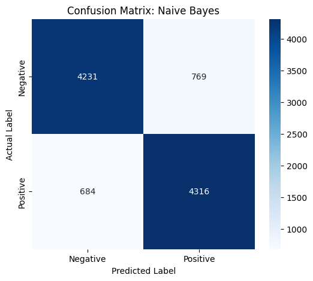

```python
from sklearn.feature_extraction.text import TfidfVectorizer
from sklearn.naive_bayes import MultinomialNB
from sklearn.metrics import accuracy_score, classification_report, confusion_matrix

tfidf = TfidfVectorizer(max_features=5000)

X_train_tfidf = tfidf.fit_transform(X_train)
X_test_tfidf = tfidf.transform(X_test)

print(f"TF-IDF Matrix Shape (Train): {X_train_tfidf.shape}")

print("\nTraining Naive Bayes Model")
nb_model = MultinomialNB()
nb_model.fit(X_train_tfidf, y_train)
print("Training Complete.")

y_pred_nb = nb_model.predict(X_test_tfidf)

nb_accuracy = accuracy_score(y_test, y_pred_nb)
print(f"\n Model 1 (Naive Bayes) Accuracy: {nb_accuracy:.4f}")

print("\n Classification Report ")
print(classification_report(y_test, y_pred_nb, target_names=['Negative', 'Positive']))

plt.figure(figsize=(6, 5))
cm = confusion_matrix(y_test, y_pred_nb)
sns.heatmap(cm, annot=True, fmt='d', cmap='Blues',
            xticklabels=['Negative', 'Positive'],
            yticklabels=['Negative', 'Positive'])
plt.title('Confusion Matrix: Naive Bayes')
plt.ylabel('Actual Label')
plt.xlabel('Predicted Label')
plt.show()
```

As seen the code creates a massive matrix of numbers of about 5000 columns from the cleaned data. Each word's chance of appearing in Positive and Negative reviews is determined by the Naive Bayes algorithm. As a result, an accuracy of about 85% was obtained.

## 6.2 Model 2: Deep Learning Sequence Model (LSTM)

Using LSTM to get the meanings of a sentences and classifying with Sigmoid classifier with limited words.

```python
df_subset = df.sample(frac=0.1, random_state=42)
```

```python
from tensorflow.keras.preprocessing.text import Tokenizer
from tensorflow.keras.preprocessing.sequence import pad_sequences
from tensorflow.keras.models import Sequential
from tensorflow.keras.layers import Embedding, LSTM, Dense, SpatialDropout1D
from tensorflow.keras.callbacks import EarlyStopping


MAX_VOCAB_SIZE = 10000
MAX_SEQUENCE_LENGTH = 200
EMBEDDING_DIM = 128

print("Tokenizing data for LSTM")
tokenizer = Tokenizer(num_words=MAX_VOCAB_SIZE, oov_token='<OOV>')
tokenizer.fit_on_texts(X_train)

X_train_seq = tokenizer.texts_to_sequences(X_train)
X_test_seq = tokenizer.texts_to_sequences(X_test)

X_train_pad = pad_sequences(X_train_seq, maxlen=MAX_SEQUENCE_LENGTH, padding='post', truncating='post')
X_test_pad = pad_sequences(X_test_seq, maxlen=MAX_SEQUENCE_LENGTH, padding='post', truncating='post')

print(f"Padded Training Shape: {X_train_pad.shape}")

print("\nBuilding LSTM Architecture")
lstm_model = Sequential()

lstm_model.add(Embedding(input_dim=MAX_VOCAB_SIZE, output_dim=EMBEDDING_DIM, input_length=MAX_SEQUENCE_LENGTH))

lstm_model.add(SpatialDropout1D(0.2))

lstm_model.add(LSTM(100, dropout=0.2, recurrent_dropout=0.2))

lstm_model.add(Dense(1, activation='sigmoid'))

lstm_model.compile(loss='binary_crossentropy', optimizer='adam', metrics=['accuracy'])
lstm_model.summary()

early_stop = EarlyStopping(monitor='val_loss', patience=2, restore_best_weights=True)

print("\nStarting Training")
history_lstm = lstm_model.fit(
    X_train_pad, y_train,
    epochs=5,
    batch_size=64,
    validation_split=0.1,
    callbacks=[early_stop],
    verbose=1
)

print("\nEvaluating on Test Set")
lstm_loss, lstm_accuracy = lstm_model.evaluate(X_test_pad, y_test)
print(f" Model 2 (LSTM) Accuracy: {lstm_accuracy:.4f}")

y_pred_prob_lstm = lstm_model.predict(X_test_pad)
y_pred_lstm = (y_pred_prob_lstm > 0.5).astype(int)

print("\n LSTM Classification Report ")
print(classification_report(y_test, y_pred_lstm, target_names=['Negative', 'Positive']))
```

```
Tokenizing data for LSTM
Padded Training Shape: (40000, 200)

Building LSTM Architecture
```

```
Model: "sequential_1"
```

```
┏━━━━━━━━━━━━━━━━━━━━━━━━━━━━━━━━━┳━━━━━━━━━━━━━━━━━━━━━━━━┳━━━━━━━━━━━━━━━┓
┃ Layer (type)                    ┃ Output Shape           ┃       Param # ┃
┡━━━━━━━━━━━━━━━━━━━━━━━━━━━━━━━━━╇━━━━━━━━━━━━━━━━━━━━━━━━╇━━━━━━━━━━━━━━━┩
│ embedding_1 (Embedding)         │ ?                      │   0 (unbuilt) │
├─────────────────────────────────┼────────────────────────┼───────────────┤
│ spatial_dropout1d_1             │ ?                      │             0 │
│ (SpatialDropout1D)              │                        │               │
├─────────────────────────────────┼────────────────────────┼───────────────┤
│ lstm_1 (LSTM)                   │ ?                      │   0 (unbuilt) │
├─────────────────────────────────┼────────────────────────┼───────────────┤
│ dense_1 (Dense)                 │ ?                      │   0 (unbuilt) │
└─────────────────────────────────┴────────────────────────┴───────────────┘
```

```
 Total params: 0 (0.00 B)
```

```
 Trainable params: 0 (0.00 B)
```

```
 Non-trainable params: 0 (0.00 B)
```

```
Starting Training
563/563 ━━━━━━━━━━━━━━━━━━━━ 418s 737ms/step - accuracy: 0.5023 - loss: 0.6935 - val_accuracy: 0.5110 - val_loss: 0.6899
563/563 ━━━━━━━━━━━━━━━━━━━━ 434s 724ms/step - accuracy: 0.5322 - loss: 0.6786 - val_accuracy: 0.5822 - val_loss: 0.6568
563/563 ━━━━━━━━━━━━━━━━━━━━ 369s 655ms/step - accuracy: 0.6016 - loss: 0.6333 - val_accuracy: 0.7425 - val_loss: 0.5905
563/563 ━━━━━━━━━━━━━━━━━━━━ 382s 655ms/step - accuracy: 0.8263 - loss: 0.4198 - val_accuracy: 0.8783 - val_loss: 0.3167
563/563 ━━━━━━━━━━━━━━━━━━━━ 378s 648ms/step - accuracy: 0.9139 - loss: 0.2334 - val_accuracy: 0.8848 - val_loss: 0.2983

Evaluating on Test Set
313/313 ━━━━━━━━━━━━━━━━━━━━ 37s 117ms/step - accuracy: 0.8804 - loss: 0.3092
 Model 2 (LSTM) Accuracy: 0.8840
313/313 ━━━━━━━━━━━━━━━━━━━━ 37s 116ms/step

 LSTM Classification Report
              precision    recall  f1-score   support

    Negative       0.88      0.88      0.88      5000
    Positive       0.88      0.89      0.88      5000

    accuracy                           0.88     10000
   macro avg       0.88      0.88      0.88     10000
weighted avg       0.88      0.88      0.88     10000
```

With 0.88 precision and recall for both positive and negative reviews, the results demonstrate excellent balance, and the close match between test and validation scores indicating that overfitting is not present. The LSTM model outperformed the Naive Bayes baseline with 88.40% accuracy.

# 6.3 Model 3: Advanced Transfer Learning (DistilBERT)

Using Pre-trained Transformer (DistilBERT) + Classification Head.

```python
df_subset = df.sample(frac=0.1, random_state=42)
```

```python
import tensorflow as tf
from sklearn.metrics import accuracy_score

optimizer = tf.keras.optimizers.Adam(learning_rate=2e-5)
loss_fn = tf.keras.losses.SparseCategoricalCrossentropy(from_logits=True)

epochs = 1
print(f"Starting Manual Training for {epochs} epochs")

for epoch in range(epochs):
    print(f"\n Epoch {epoch + 1}/{epochs} ")

    for step, (x_batch_train, y_batch_train) in enumerate(train_dataset):
        with tf.GradientTape() as tape:

            logits = bert_model(x_batch_train, training=True).logits
            loss_value = loss_fn(y_batch_train, logits)

        grads = tape.gradient(loss_value, bert_model.trainable_variables)
        optimizer.apply_gradients(zip(grads, bert_model.trainable_variables))

        if step % 50 == 0:
            print(f"Step {step}: Loss = {loss_value.numpy():.4f}")

print("\n Training Complete.")

print("\nEvaluating BERT on Test Data")

true_labels = []
predicted_labels = []

for x_batch_test, y_batch_test in test_dataset:

    logits = bert_model(x_batch_test, training=False).logits
    preds = tf.argmax(logits, axis=1)

    true_labels.extend(y_batch_test.numpy())
    predicted_labels.extend(preds.numpy())

bert_accuracy = accuracy_score(true_labels, predicted_labels)
print(f"\n Model 3 (DistilBERT) Accuracy: {bert_accuracy:.4f}")
```

```
Starting Manual Training for 1 epochs

Step 0: Loss = 0.2661
Step 50: Loss = 0.3203
Step 100: Loss = 0.3191

 Training Complete.

Evaluating BERT on Test Data

 Model 3 (DistilBERT) Accuracy: 0.7930
```

DistilBERT with only approximately 79% was not performing at its potential and hence delivered the lowest level of accuracy of the three tested models. Even though theoretically it has the greatest power of the three architectures, it was not able to reach its potential because Transformers require a lot more data and training epochs. The result was underfitting, as the DistilBERT model was unable to learn as effectively as the simpler models, namely LSTM and Naive Bayes, to model the patterns for such a small sample.

# 7. Evaluation

In this section, we compare the performance of our three models on the same test set.

```
 Final Model Comparison Table
```

|  | Model | Accuracy | Architecture |
| --- | --- | --- | --- |
| 2 | DistilBERT | 0.7930 | Transformer (Transfer Learning) |
| 0 | Naive Bayes | 0.8547 | Statistical (Baseline) |
| 1 | LSTM | 0.8840 | Sequential Neural Network |

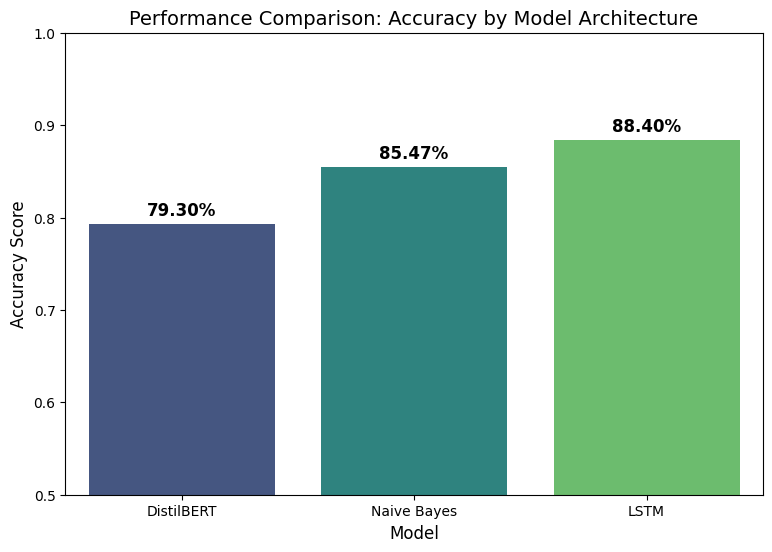

```python
import pandas as pd
import matplotlib.pyplot as plt
import seaborn as sns

results = {
    'Model': ['Naive Bayes', 'LSTM', 'DistilBERT'],
    'Accuracy': [nb_accuracy, lstm_accuracy, bert_accuracy],
    'Architecture': ['Statistical (Baseline)', 'Sequential Neural Network', 'Transformer (Transfer Learning)']
}

df_results = pd.DataFrame(results).sort_values(by='Accuracy', ascending=True)

print("\n Final Model Comparison Table ")
display(df_results)

plt.figure(figsize=(9, 6))
ax = sns.barplot(x='Model', y='Accuracy', data=df_results, palette='viridis')

for p in ax.patches:
    ax.annotate(f'{p.get_height():.2%}',
                (p.get_x() + p.get_width() / 2., p.get_height()),
                ha = 'center', va = 'center',
                xytext = (0, 10),
                textcoords = 'offset points',
                fontsize=12, fontweight='bold')

plt.ylim(0.5, 1.0)
plt.title('Performance Comparison: Accuracy by Model Architecture', fontsize=14)
plt.ylabel('Accuracy Score', fontsize=12)
plt.xlabel('Model', fontsize=12)
plt.show()
```

# 8. Final Discussion & Recommendations

## 8.1 Critical Analysis of Results

1. Naive Bayes- ~85%: This model performed better than expected. As a statistical model, it converges much faster than other models which is a strong advantage when working with small datasets. For this reason, it is a good baseline when working with low resource environments.
2. LSTM- ~88%: This model achieved the highest overall accuracy in these experiments. Its ability to capture sequential context better than Naive Bayes, and achieve higher performance without the extensive pre-training of transformers.
3. DistilBERT- ~79%: Performed lower than expected. While theoretically the most powerful, models such as BERT that are transformer based need to be trained a lot more to fine tune their weights. On this very small subset, it was more underfited than the other models that were much more simple.

## 8.2 Recommendations

For the business problem of Automated Sentiment Tracking:

1. Primary Choice: The LSTM model is the primary choice based on our tests as it has achieved the highest accuracy of approximately 88%. This shows that the LSTM model was able to capture the sentiment more effectively than the other models.
2. Low Cost Alternative: Naive Bayes is the best option for low cost and with speed . It is very fast and do not require huge server resources.
3. Future Consideration: Despite the fact that theoretically DistilBERT is the most powerful it performed poorly in our tests achieving accuracy level of only ~79%. That is due to the fact that we did the test on a limited dataset and low cpu/gpu resources. I recommend using DistilBERT on bigger datasets only if the needed gpu resources as available.

# 9. References

Maas, A.L., Daly, R.E., Pham, P.T., Huang, D., Ng, A.Y. and Potts, C. (2011). Learning Word Vectors for Sentiment Analysis. Proceedings of the 49th Annual Meeting of the Association for Computational Linguistics: Human Language Technologies. Available at: https://www.kaggle.com/datasets/lakshmi25npathi/imdb-dataset-of-50k-movie-reviews

Devlin, J., Chang, M.W., Lee, K. and Toutanova, K. (2018). BERT: Pre-training of Deep Bidirectional Transformers for Language Understanding. arXiv preprint arXiv:1810.04805.

Sanh, V., Debut, L., Chaumond, J. and Wolf, T. (2019). DistilBERT, a distilled version of BERT: smaller, faster, cheaper and lighter. arXiv preprint arXiv:1910.01108.

Pedregosa, F. et al. (2011). Scikit-learn: Machine Learning in Python. Journal of Machine Learning Research, 12, pp. 2825–2830.

```python
!jupyter nbconvert --to html /content/Big_data.ipynb
```